# Statistical inference with the GSS data

## Setup

### Load packages

```r
library(ggplot2)
library(dplyr)
library(statsr)
library(tidyr)
library(scales)
library(ggthemes)
```

```r
load("gss.Rdata")
```

## Part 1: Data

The GSS gathers data to seek to monitor and explain trends in American attitudes, behaviors, and attributes. Data is gathered via in-person interviews that average 90 minutes in length. All U.S. households had an equal chance of being selected.

While the chance to be selected is random, actual responders are likely not random. First, 90 minutes is long. I anticipate a bias toward people who have more free time such as older Americans without young kids. Second, many potential interviees may view the interviewers as security risks, so I anticipate a bias toward stronger individuals and/or men. Third, many people will not be willing to share such personal information with a stranger so a bias may exist toward parts of the country in which openness is more common. Fourth, the survey focuses on households so ignores homeless citizens.

For above reasons, causality cannot be inferred to all citizens in the United States.

## Part 2: Research question

I am interested in whether Americans’ views on assisted suicide for individuals with incurable diseases are dependent on whether the respondent states a with a religious affiliation.

My interest stems from two factors. First, I recently watched my mother suffer from pancreatic cancer. She was miserable when could no longer receive treatment and wanted to die. Second, I am empathetic with my mother but feel conflicted from my Christian belief that the decision to die sits with God.

## Part 3: Exploratory data analysis

```r
gss %>%
  filter (year == 2012, !is.na(suicide2)) %>%
  group_by (suicide2) %>%
  summarize (n = n()) %>%
  mutate (pct = n/sum(n))
```

```
## # A tibble: 2 x 3
##   suicide2     n   pct
##   <fct>    <int> <dbl>
## 1 Yes        144 0.113
## 2 No        1127 0.887
```

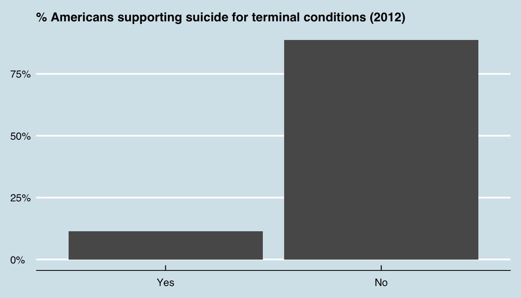

```r
gss %>%
  filter (year == 2012, !is.na(suicide2)) %>%
  ggplot (aes (x=suicide2)) +
    geom_bar (aes(y = (..count..)/sum(..count..))) +
    theme_economist() +
    ggtitle ("% Americans supporting suicide for terminal conditions (2012)") +
        theme(plot.title = element_text(size = 12, face = "bold")) +
    xlab (NULL) +
    ylab (NULL) +
    scale_y_continuous(labels=percent)
```

A majority of Americans are against assisted suicide for patients with terminal conditions. Only 11% are expressly in favor of the option.

```r
gss %>%
  filter (year == 2012, !is.na (relig), !is.na(suicide2)) %>%
  mutate (religious = if_else(relig == "None", "No", "Yes")) %>%
  group_by (religious, suicide2) %>%
  summarize (n = n()) %>%
  mutate (pct = n/sum(n)) %>%
  select (-n) -> gss_summ

gss_summ %>%
  spread (suicide2, pct)
```

```
## # A tibble: 2 x 3
## # Groups:   religious [2]
##   religious    Yes    No
##   <chr>      <dbl> <dbl>
## 1 No        0.231  0.769
## 2 Yes       0.0821 0.918
```

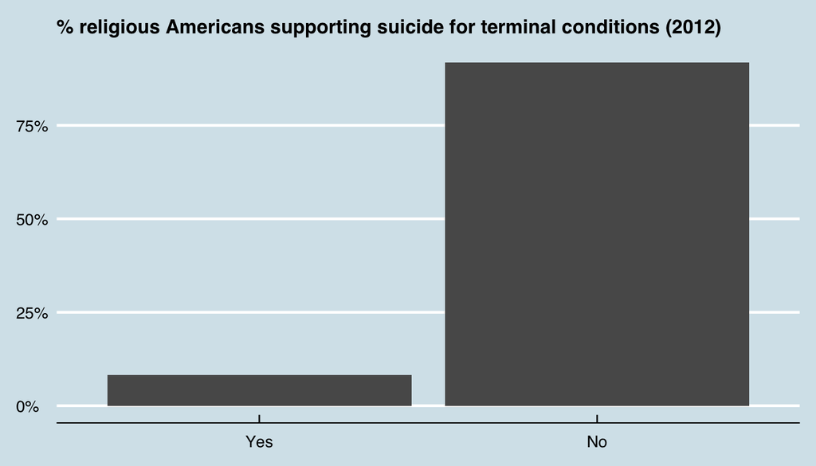

```r
gss %>%
  filter (!is.na (relig), !is.na(suicide2)) %>%
  mutate (religious = if_else(relig == "None", "No", "Yes")) %>%
  filter (year == 2012 & religious == "Yes") %>%
  ggplot (aes (x=suicide2)) +
    geom_bar (aes(y = (..count..)/sum(..count..))) +
    theme_economist() +
    ggtitle ("% religious Americans supporting suicide for terminal conditions (2012)") +
        theme(plot.title = element_text(size = 12, face = "bold")) +
    xlab (NULL) +
    ylab (NULL) +
    scale_y_continuous(labels=percent)
```

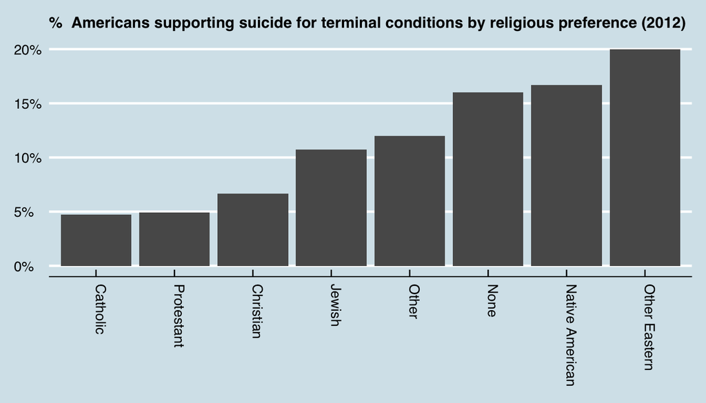

```r
gss %>%
  filter (year == 2012) %>%
  group_by (relig, suicide2) %>%
  summarize (n = n()) %>%
  mutate (pct = n/sum(n)) %>%
  filter (suicide2 == "Yes") %>%
  select (-n, -suicide2) %>%
  ggplot (aes (x=reorder(relig, pct), y = pct)) +
    geom_col () +
    theme_economist() +
    ggtitle ("%  Americans supporting suicide for terminal conditions by religious preference (2012)") +
        theme(plot.title = element_text(size = 11, face = "bold")) +
    xlab (NULL) +
    ylab (NULL) +
    scale_y_continuous(labels=percent) +
    theme(axis.text.x=element_text(angle = -90, hjust = 0))
```

## Part 4: Inference

I selected a Chi-squared test for independence because two categorical variables (religious affiliation, support for assisted suicide with a terminal condition) with multiple levels for each. I am using a 95% critical value.

My inference study will be a hypothesis test instead of a confidence interval because I have two categorical variables, one of which has more than two levels.

The null hypothesis is that support for assisted suicide for patients with terminal conditions does not depend on stated religious preference. The alternate hypothesis is that support for assisted suicide for patients with terminal conditions does depend on religious preference.

The conditions for testing are twofold. The first is a random sample from the U.S. population. As discussed in the Data section above, the GSS study is not fully random so inference conclusions from the study need to be tempered. Second, data in count buckets need to be ≥ 5. Some buckets for specific religious preferences are indeed less than 6. I contemplated combining the religions with small sample size into an Other category. However, I decided would be non-sensical because these religions have very different beliefs so removed from the study.

```r
gss_table <- table (gss$suicide2,gss$relig)
gss_table
```

```
##
##       Protestant Catholic Jewish  None Other Buddhism Hinduism
##   Yes       1071      426    121   710    74       12        3
##   No       16094     6835    471  2586   458       55       32
##
##       Other Eastern Moslem/Islam Orthodox-Christian Christian
##   Yes             3            6                  3        26
##   No              6           58                 37       295
##
##       Native American Inter-Nondenominational
##   Yes               4                       6
##   No               12                      54
```

```r
chisq.test(gss_table)
```

```
##
##  Pearson's Chi-squared test
##
## data:  gss_table
## X-squared = 1061.8, df = 12, p-value < 2.2e-16
```

The count of American of preferences for specific religions is below 5 so violates one of the required conditions. As stated above, I contemplated combining the religions with small sample size into an Other category. However, I decided would be non-sensical because these religions have very different beliefs so removed from the study.

```r
gss$relig2 <- as.character (gss$relig)

gss2 <- gss %>%
  filter (relig2 == "Catholic" | relig2 == "Christian" | relig2 == "Protestant" | relig2 == "Jewish")

gss_table <- table (gss2$suicide2,gss2$relig2)
gss_table
```

```
##
##       Catholic Christian Jewish Protestant
##   Yes      426        26    121       1071
##   No      6835       295    471      16094
```

```r
chisq.test(gss_table)
```

```
##
##  Pearson's Chi-squared test
##
## data:  gss_table
## X-squared = 197.66, df = 3, p-value < 2.2e-16
```

Chi-squared tests for independence using hypothesis tests are the only tests I am aware of for two categorical variables with one having multiple levels. I am unaware of what else could be compared with the study results.

Future studies could potentially run chi-squared tests of independence on other potential variables such as region of country, age and income. That said, I would be wary of insightfulness of such studies due to the lack of randomness in surveying Americans as noted in data section above.